# Project: Why don't people show up on their medical appointments?

- Introduction
- Data Wrangling
- Exploratory Data Analysis
- Conclusions
- References

## Introduction

For one reason or another, people sometimes **don't show up** for their medical appointments which could casue the waste of the medical resources and other negative impact.  
The [dataset](https://s3.amazonaws.com/video.udacity-data.com/topher/2018/July/5b57919a_data-set-options/data-set-options.pdf) we used collected information from 100k medical appointments in Brazil and is focused on the question of whether or not patients show up for their appointment. **So what factors are important to predict whether a patient will show up for their scheduled appointment or not?**  
Let's find trends among the patients who didn’t show up！

First import everything we need and then begin with the data wrangling! : )

```python
import pandas as pd
import numpy as np
import matplotlib.pyplot as plt
%matplotlib inline
```

## Data Wrangling

In this section, I'm going to wrangling with data types, missing data, any errant data as well as modify the data if needed.

### General Properties

Have a whole picture of the dataset first，the structure of the data and any problems that need to be cleaned.

```python
df = pd.read_csv('noshowappointments.csv')
df.head()
```

|  | PatientId | AppointmentID | Gender | ScheduledDay | AppointmentDay | Age | Neighbourhood | Scholarship | Hipertension | Diabetes | Alcoholism | Handcap | SMS_received | No-show |
| --- | --- | --- | --- | --- | --- | --- | --- | --- | --- | --- | --- | --- | --- | --- |
| 0 | 2.987250e+13 | 5642903 | F | 2016-04-29T18:38:08Z | 2016-04-29T00:00:00Z | 62 | JARDIM DA PENHA | 0 | 1 | 0 | 0 | 0 | 0 | No |
| 1 | 5.589978e+14 | 5642503 | M | 2016-04-29T16:08:27Z | 2016-04-29T00:00:00Z | 56 | JARDIM DA PENHA | 0 | 0 | 0 | 0 | 0 | 0 | No |
| 2 | 4.262962e+12 | 5642549 | F | 2016-04-29T16:19:04Z | 2016-04-29T00:00:00Z | 62 | MATA DA PRAIA | 0 | 0 | 0 | 0 | 0 | 0 | No |
| 3 | 8.679512e+11 | 5642828 | F | 2016-04-29T17:29:31Z | 2016-04-29T00:00:00Z | 8 | PONTAL DE CAMBURI | 0 | 0 | 0 | 0 | 0 | 0 | No |
| 4 | 8.841186e+12 | 5642494 | F | 2016-04-29T16:07:23Z | 2016-04-29T00:00:00Z | 56 | JARDIM DA PENHA | 0 | 1 | 1 | 0 | 0 | 0 | No |

```python
df.shape
```

```
(110527, 14)
```

As we can see, some columns names are not correct or clear. We will fix them later.  
Now let's check the **data types**,**null data** and **duplicates**.

```python
df.info()
```

```
<class 'pandas.core.frame.DataFrame'>
RangeIndex: 110527 entries, 0 to 110526
Data columns (total 14 columns):
PatientId         110527 non-null float64
AppointmentID     110527 non-null int64
Gender            110527 non-null object
ScheduledDay      110527 non-null object
AppointmentDay    110527 non-null object
Age               110527 non-null int64
Neighbourhood     110527 non-null object
Scholarship       110527 non-null int64
Hipertension      110527 non-null int64
Diabetes          110527 non-null int64
Alcoholism        110527 non-null int64
Handcap           110527 non-null int64
SMS_received      110527 non-null int64
No-show           110527 non-null object
dtypes: float64(1), int64(8), object(5)
memory usage: 11.8+ MB
```

```python
df.duplicated().sum()
```

```
0
```

```python
df.isnull().sum()
```

```
PatientId         0
AppointmentID     0
Gender            0
ScheduledDay      0
AppointmentDay    0
Age               0
Neighbourhood     0
Scholarship       0
Hipertension      0
Diabetes          0
Alcoholism        0
Handcap           0
SMS_received      0
No-show           0
dtype: int64
```

We need to change the data types of ScheduledDay and AppointmentDay to datetime. Luckly, we don't have any null data or duplicates.

Let's have a quick check to see if there are any outliers.

```python
df.describe()
```

|  | PatientId | AppointmentID | Age | Scholarship | Hipertension | Diabetes | Alcoholism | Handcap | SMS_received |
| --- | --- | --- | --- | --- | --- | --- | --- | --- | --- |
| count | 1.105270e+05 | 1.105270e+05 | 110527.000000 | 110527.000000 | 110527.000000 | 110527.000000 | 110527.000000 | 110527.000000 | 110527.000000 |
| mean | 1.474963e+14 | 5.675305e+06 | 37.088874 | 0.098266 | 0.197246 | 0.071865 | 0.030400 | 0.022248 | 0.321026 |
| std | 2.560949e+14 | 7.129575e+04 | 23.110205 | 0.297675 | 0.397921 | 0.258265 | 0.171686 | 0.161543 | 0.466873 |
| min | 3.921784e+04 | 5.030230e+06 | -1.000000 | 0.000000 | 0.000000 | 0.000000 | 0.000000 | 0.000000 | 0.000000 |
| 25% | 4.172614e+12 | 5.640286e+06 | 18.000000 | 0.000000 | 0.000000 | 0.000000 | 0.000000 | 0.000000 | 0.000000 |
| 50% | 3.173184e+13 | 5.680573e+06 | 37.000000 | 0.000000 | 0.000000 | 0.000000 | 0.000000 | 0.000000 | 0.000000 |
| 75% | 9.439172e+13 | 5.725524e+06 | 55.000000 | 0.000000 | 0.000000 | 0.000000 | 0.000000 | 0.000000 | 1.000000 |
| max | 9.999816e+14 | 5.790484e+06 | 115.000000 | 1.000000 | 1.000000 | 1.000000 | 1.000000 | 4.000000 | 1.000000 |

There seems to have outliers in "Age", we can have a double check later.  
Now let's cleaning the data!

### Drop the columns we don't need

```python
df.head(1)
```

|  | PatientId | AppointmentID | Gender | ScheduledDay | AppointmentDay | Age | Neighbourhood | Scholarship | Hipertension | Diabetes | Alcoholism | Handcap | SMS_received | No-show |
| --- | --- | --- | --- | --- | --- | --- | --- | --- | --- | --- | --- | --- | --- | --- |
| 0 | 2.987250e+13 | 5642903 | F | 2016-04-29T18:38:08Z | 2016-04-29T00:00:00Z | 62 | JARDIM DA PENHA | 0 | 1 | 0 | 0 | 0 | 0 | No |

drop 'AppointmentID' column.

```python
df.drop(columns = ['AppointmentID','Neighbourhood'],inplace = True)
```

### Fix typo

```python
df.rename(columns={'Hipertension':"Hypertension",'Handcap':"Handicap",'No-show':"No_show"},inplace = True)
```

### Drop outliers

```python
# first find the outliers
df[df.Age.values < 0]
df.drop(index = df[df.Age.values < 0].index, inplace = True)

# check again
df[df.Age.values < 0]
```

|  | PatientId | Gender | ScheduledDay | AppointmentDay | Age | Scholarship | Hypertension | Diabetes | Alcoholism | Handicap | SMS_received | No_show |
| --- | --- | --- | --- | --- | --- | --- | --- | --- | --- | --- | --- | --- |

### Fix data type

```python
df.head(1)
```

|  | PatientId | Gender | ScheduledDay | AppointmentDay | Age | Scholarship | Hypertension | Diabetes | Alcoholism | Handicap | SMS_received | No_show |
| --- | --- | --- | --- | --- | --- | --- | --- | --- | --- | --- | --- | --- |
| 0 | 2.987250e+13 | F | 2016-04-29T18:38:08Z | 2016-04-29T00:00:00Z | 62 | 0 | 1 | 0 | 0 | 0 | 0 | No |

```python
type(df.ScheduledDay[0]),type(df.AppointmentDay[0])
```

```
(str, str)
```

```python
df.ScheduledDay = pd.to_datetime(df.ScheduledDay)
df.AppointmentDay = pd.to_datetime(df.AppointmentDay)

type(df.ScheduledDay[0]),type(df.AppointmentDay[0])
```

```
(pandas._libs.tslibs.timestamps.Timestamp,
 pandas._libs.tslibs.timestamps.Timestamp)
```

### Add useful columns

I want to explore how the appointment time ( the day of week ) and waiting time ( the time between scheduled day and appointment day ) influenced the results, so I'm going to add those two columns.

```python
df['DayOfWeek'] = df.ScheduledDay.dt.dayofweek
df.head()
```

|  | PatientId | Gender | ScheduledDay | AppointmentDay | Age | Scholarship | Hypertension | Diabetes | Alcoholism | Handicap | SMS_received | No_show | DayOfWeek |
| --- | --- | --- | --- | --- | --- | --- | --- | --- | --- | --- | --- | --- | --- |
| 0 | 2.987250e+13 | F | 2016-04-29 18:38:08+00:00 | 2016-04-29 00:00:00+00:00 | 62 | 0 | 1 | 0 | 0 | 0 | 0 | No | 4 |
| 1 | 5.589978e+14 | M | 2016-04-29 16:08:27+00:00 | 2016-04-29 00:00:00+00:00 | 56 | 0 | 0 | 0 | 0 | 0 | 0 | No | 4 |
| 2 | 4.262962e+12 | F | 2016-04-29 16:19:04+00:00 | 2016-04-29 00:00:00+00:00 | 62 | 0 | 0 | 0 | 0 | 0 | 0 | No | 4 |
| 3 | 8.679512e+11 | F | 2016-04-29 17:29:31+00:00 | 2016-04-29 00:00:00+00:00 | 8 | 0 | 0 | 0 | 0 | 0 | 0 | No | 4 |
| 4 | 8.841186e+12 | F | 2016-04-29 16:07:23+00:00 | 2016-04-29 00:00:00+00:00 | 56 | 0 | 1 | 1 | 0 | 0 | 0 | No | 4 |

The day of the week with Monday=0, Sunday=6.  
Now create the "WaitingTime" column and change the unit of time to day.

```python
df['WaitingTime'] = df.AppointmentDay.dt.date -  df.ScheduledDay.dt.date
df.WaitingTime = df.WaitingTime.astype(str)
type(df.WaitingTime[0])
```

```
str
```

```python
df.WaitingTime = df.WaitingTime.map(lambda x : x.split(' ')[0]).astype(int)
```

```python
type(df.WaitingTime[0])
```

```
numpy.int64
```

Now let's check if there are any outliers.

```python
df.WaitingTime.describe()
```

```
count    110526.000000
mean         10.183794
std          15.255034
min          -6.000000
25%           0.000000
50%           4.000000
75%          15.000000
max         179.000000
Name: WaitingTime, dtype: float64
```

```python
df[(df.WaitingTime < 0)].WaitingTime
```

```
27033   -1
55226   -1
64175   -1
71533   -6
72362   -1
Name: WaitingTime, dtype: int64
```

### Drop some cloumns again

##### Make the dataframe cleaner

```python
df.drop(columns = ['AppointmentDay','ScheduledDay'],inplace = True)
```

## Exploratory Data Analysis

### Q1: Did waiting time influence the show-up?

```python
df.head(1)
```

|  | PatientId | Gender | Age | Scholarship | Hypertension | Diabetes | Alcoholism | Handicap | SMS_received | No_show | DayOfWeek | WaitingTime |
| --- | --- | --- | --- | --- | --- | --- | --- | --- | --- | --- | --- | --- |
| 0 | 2.987250e+13 | F | 62 | 0 | 1 | 0 | 0 | 0 | 0 | No | 4 | 0 |

Some histograms and bar charts were used in order to make the data more clearly and easy to understand, thus two functions related to chart_make were built to avoid repetitive code.

```python
def create_the_multihist(df, column, title, xlabel, ylabel):
    show = df['No_show'] == "No"
    not_show = df['No_show'] == "Yes"
    df[show][column].hist(bins = 30, label = 'Show', alpha = .7)
    df[not_show][column].hist(bins = 30, label = 'No-show', alpha = .7)
    plt.title(title)
    plt.xlabel(xlabel)
    plt.ylabel(ylabel)
    plt.legend()

    return plt.show();
```

```python
def create_bar_chart(x, y, bars, title, xlabel, ylabel):
    height = [x, y]
    plt.bar([1.3, 2], height, tick_label = bars, color = ['pink','skyblue'], width = 0.45);
    plt.title(title, fontsize = 14)
    plt.xlabel(xlabel,fontsize = 14)
    plt.ylabel(ylabel, fontsize = 14)

    return plt.show();
```

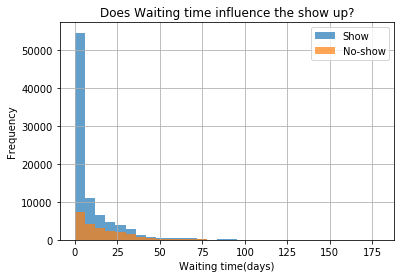

```python
df_new = df[df.WaitingTime >= 0]

create_the_multihist(df_new, 'WaitingTime', 'Does Waiting time influence the show up?', "Waiting time(days)", "Frequency")
```

As is clearly shown in the plot, when the waiting time was very short, the percentages of show-up were quite high.  
As the waiting time became longer ,the percentage of people who missed the appointment became bigger.

### Q2: Did Appointment day influence the show-up?

```python
show = df.No_show == "No"
not_show = df.No_show == "Yes"
```

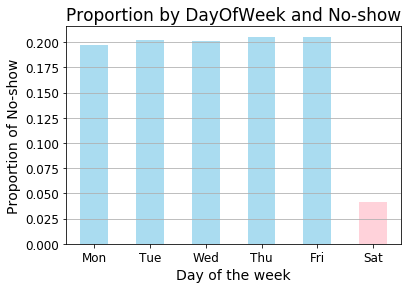

```python
df1 = df[show].groupby('DayOfWeek').count().No_show
df2 = df[not_show].groupby('DayOfWeek').count().No_show
proportions = (df2/(df1+df2))
colors = ['skyblue', 'skyblue', 'skyblue', 'skyblue', 'skyblue', 'pink']
bars = ['Mon', 'Tue', 'Wed', 'Thu', 'Fri', 'Sat']

proportions.plot(kind = 'bar',color = colors, fontsize = 12, alpha = .7);
plt.xticks(np.arange(6), bars, rotation=360)
plt.title('Proportion by DayOfWeek and No-show',fontsize = 17)
plt.xlabel('Day of the week',fontsize = 14)
plt.ylabel('Proportion of No-show', fontsize = 14)
plt.grid(axis="y");
```

As is clearly shown in the plot, people who didn't show up from monday to Friday is stable at around 20%, **while on saturday**, people are more likely to **not miss the appointment**.  
There were very few people who was be able to made an appointment on Saturday, which means only in the emergency special situations, thus showing up was reasonable.

### Q3: Did the gender of patients influence the show-up?

```python
total = df.groupby('Gender').count().No_show
total
```

```
Gender
F    71839
M    38687
Name: No_show, dtype: int64
```

The data shows an interesting result that **female are generally more often go to the doctor**,  
which may indicate that **woman are more likely to seek for health care than man do**.  
Now let's see if they show up on an appointment.

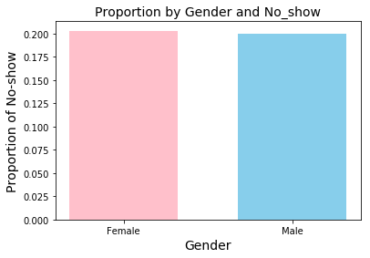

```python
ProportionF = (df[not_show].Gender.value_counts()['F'])/total['F']
ProportionM = (df[not_show].Gender.value_counts()['M'])/total['M']

create_bar_chart(ProportionF, ProportionM, ['Female', 'Male'], 'Proportion by Gender and No_show', 'Gender', 'Proportion of No-show')
```

Although female are more likely to seek for health care support, the frequency of missing the appointment is almost the same.

### Q4: Did the age of patients influence the show-up?

```python
df.head(1)
```

|  | PatientId | Gender | Age | Scholarship | Hypertension | Diabetes | Alcoholism | Handicap | SMS_received | No_show | DayOfWeek | WaitingTime |
| --- | --- | --- | --- | --- | --- | --- | --- | --- | --- | --- | --- | --- |
| 0 | 2.987250e+13 | F | 62 | 0 | 1 | 0 | 0 | 0 | 0 | No | 4 | 0 |

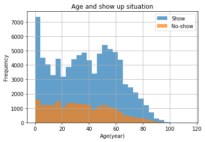

```python
create_the_multihist(df, 'Age', 'Age and show up situation', "Age(year)", "Frequency")
```

```python
bins = [0,10,20,30,40,50,60,70,120]
df['Age_bins'] = pd.cut(df['Age'], bins, right = False)
# df.groupby('Age_bins').count()
df1 = df[not_show].groupby('Age_bins').count().PatientId
df2 =df[show].groupby('Age_bins').count().PatientId
df1, df2
```

```
(Age_bins
 [0, 10)      3484
 [10, 20)     3257
 [20, 30)     3380
 [30, 40)     3300
 [40, 50)     2880
 [50, 60)     2776
 [60, 70)     1790
 [70, 120)    1452
 Name: PatientId, dtype: int64, Age_bins
 [0, 10)      13991
 [10, 20)      9679
 [20, 30)     10319
 [30, 40)     11871
 [40, 50)     11329
 [50, 60)     13087
 [60, 70)     10086
 [70, 120)     7845
 Name: PatientId, dtype: int64)
```

```python
proportions = df1/(df1+df2)
proportions
```

```
Age_bins
[0, 10)      0.199371
[10, 20)     0.251778
[20, 30)     0.246733
[30, 40)     0.217520
[40, 50)     0.202688
[50, 60)     0.174998
[60, 70)     0.150724
[70, 120)    0.156179
Name: PatientId, dtype: float64
```

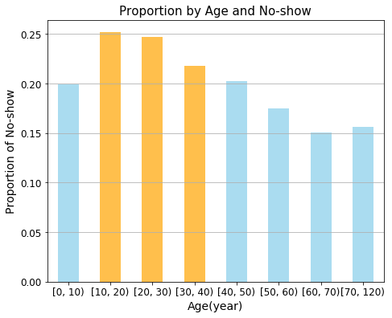

```python
colors = ['skyblue', 'orange', 'orange', 'orange', 'skyblue', 'skyblue', 'skyblue', 'skyblue']

proportions.plot(kind = 'bar', color = colors, fontsize = 12, alpha = .7, figsize = (7.5,6));
plt.xticks(rotation=360)
plt.title('Proportion by Age and No-show',fontsize = 15)
plt.xlabel('Age(year)',fontsize = 14)
plt.ylabel('Proportion of No-show', fontsize = 14)
plt.grid(axis="y");
```

As is clearly shown in the plot, teenagers and young adults are more likely to miss the appointment than children and old people.

### Q5: Did the welfare program influence the show-up ?

Although i don't think the location influence the hehavior, let's have a check.

```python
Scholarship = df[df.Scholarship.astype(bool)]
df1 = len(Scholarship[Scholarship.No_show == 'Yes'])
total1 = len(Scholarship)
Proportion1 = df1/total1
Proportion1
```

```
0.2373630420771568
```

```python
No_Scholarship = df[df.Scholarship == 0]
df2 = len(No_Scholarship[No_Scholarship.No_show == 'Yes'])
total2 = len(No_Scholarship)
Proportion2 = df2/total2
Proportion2
```

```
0.19807354638037425
```

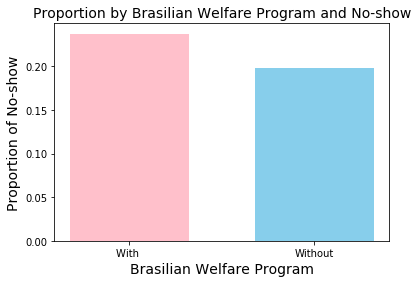

```python
create_bar_chart(Proportion1, Proportion2, ['With ', 'Without'], 'Proportion by Brasilian Welfare Program and No-show', 'Brasilian Welfare Program', 'Proportion of No-show')
```

People who enrolled in Brasilian Welfare Program were more likely to miss the appointment compared with people who don't have financial support. In some countries, people even get a fine for not showing up to the appointment. Obviously, people who don't have the financial support are more care about the money.

### Q6: Did the types of disease influence the show-up ?

```python
Alcoholism = df[df.Alcoholism.astype(bool)]
df1 = len(Alcoholism[Alcoholism.No_show == 'Yes'])
total1 = len(Alcoholism)
Proportion1 = df1/total1

No_Alcoholism = df[df.Alcoholism == 0]
df2 = len(No_Alcoholism[No_Alcoholism.No_show == 'Yes'])
total2 = len(No_Alcoholism)
Proportion2 = df2/total2


Proportion1, Proportion2
```

```
(0.20148809523809524, 0.20194837915010358)
```

With Alcoholism or not, the proportions of No-show are nearly equal. Now let's have a look at the 'Hypertension'.

```python
Hypertension = df[df.Hypertension.astype(bool)]
df1 = len(Hypertension[Hypertension.No_show == 'Yes'])
total1 = len(Hypertension)
Proportion1 = df1/total1

No_Hypertension = df[df.Hypertension == 0]
df2 = len(No_Hypertension[No_Hypertension.No_show == 'Yes'])
total2 = len(No_Hypertension)
Proportion2 = df2/total2


Proportion1, Proportion2
```

```
(0.17301958625751113, 0.2090391659622429)
```

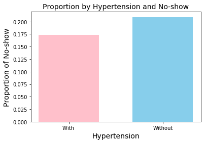

```python
create_bar_chart(Proportion1, Proportion2, ['With ', 'Without'], 'Proportion by Hypertension and No-show', 'Hypertension', 'Proportion of No-show')
```

The people who have Hypertension are more likely to show up in time to the appointment compare with the people who don't.

```python
Diabetes = df[df.Diabetes.astype(bool)]
df1 = len(Diabetes[Diabetes.No_show == 'Yes'])
total1 = len(Diabetes)
Proportion1 = df1/total1

No_Diabetes = df[df.Diabetes == 0]
df2 = len(No_Diabetes[No_Diabetes.No_show == 'Yes'])
total2 = len(No_Diabetes)
Proportion2 = df2/total2

Proportion1, Proportion2
```

```
(0.18003273322422259, 0.20363023112991432)
```

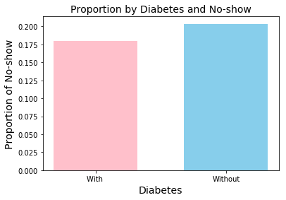

```python
create_bar_chart(Proportion1, Proportion2, ['With ', 'Without'], 'Proportion by Diabetes and No-show', 'Diabetes', 'Proportion of No-show')
```

The people who have Diabetes are more likely to show up in time to the appointment compare with the people who don't.

### Q7: Did the SMS influence the show-up ?

```python
df_new = df[df.WaitingTime >= 0]
```

```python
SMS_received = df_new[df_new.SMS_received.astype(bool)]
df1 = len(SMS_received[SMS_received.No_show == 'Yes'])
total1 = len(SMS_received)
Proportion1 = df1/total1

No_SMS_received = df_new[df_new.SMS_received == 0]
df2 = len(No_SMS_received[No_SMS_received.No_show == 'Yes'])
total2 = len(No_SMS_received)
Proportion2 = df2/total2

Proportion1, Proportion2
```

```
(0.27574544839637, 0.16697983715134795)
```

It was mind blowing to me since i thought receiving SMS was supposed to remind people of the appointment, but the data showed the opposite.

Then I checked the relationship between WaitingTime and SMS_received, to see if people received the SMS becasue of the long Waiting time.

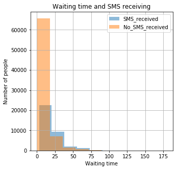

```python
SMS_received.WaitingTime.hist(alpha = 0.5, bins = 10, label = 'SMS_received', figsize = (5,5));
No_SMS_received.WaitingTime.hist(alpha = 0.5, bins = 10, label = 'No_SMS_received');
plt.title('Waiting time and SMS receiving')
plt.xlabel('Waiting time')
plt.ylabel('Number of people')
plt.legend();
```

It seems that the longer the waiting time is, the higher the proportion of SMS_received is. Thus this may perfectly explain why people who received SMS were also likely to miss the appointment, becasue their waiting time was also longer.

### Just curious: Were there people who missed the appoimtment more than once?

```python
df.PatientId.duplicated().sum()
```

```
48228
```

There were many people went to the doctor more than once.

```python
df1 = df[not_show]
df[not_show].groupby('PatientId').count().No_show.sort_values(ascending = False).head(5)
```

```
PatientId
1.421987e+12    18
5.635135e+14    16
5.587790e+12    15
5.811973e+14    14
6.575144e+13    13
Name: No_show, dtype: int64
```

As we can see from data, actually there are lots of people(same PatientId indicates the same person) who missed the appointments more than once, the top one even missed 18 times 😲.

## Conclusions

### Results

#### There are a few influencing factors that may related to missing appointment :

- **Appointment time**  
  Appointments that were made in weekends has a higher show-up rate compared with in weekdays.
- **Waiting time**  
  It seems that the longer waiting time was, the easier people were going to miss the appointment. Unfortunately, receiving SMS was not likely to help people show up on the appointment, Which may also indicate that, most of the time, the reason why people miss the appointment is not because they forget, is because they really need to do something else at that time.
- **The age of patients**  
  Teenagers and young adults are more likely to miss the appointment than children and old people.
- **The welfare program**  
  People who enrolled in Brazilian Welfare Program were more likely to miss the appointment compared with people who don't have financial support.
- **Types of disease**  
  The people who have Hypertension and Diabetes are more likely to show up in time to the appointment.

### Limitations

#### There are a few limitations with our data:

- **No inferential statistics**

  We didn't do any controlled or hypotheses experiments, so no infernces was created.
- **More details is needed**

  In order to draw more accurate conclusions, further investigations and data collection are needed here. For instance, data only shows the day of Appointment instead of the accurate time and we also don't know when and how can people receive the SMS.
- **Lack of numerical data**  
  As most of our data is categorical, we cannot see if there are strong correlations between our variables.

## References

1 [pandas.df.drop](https://pandas.pydata.org/pandas-docs/stable/reference/api/pandas.DataFrame.drop.html)  
2 lowercase  
3 [datetime](https://stackoverflow.com/questions/30405413/python-pandas-extract-year-from-datetime-dfyear-dfdate-year-is-not)  
4 [bar chart](https://python-graph-gallery.com/4-add-title-and-axis-label/)

```python
from subprocess import call
call(['python', '-m', 'nbconvert', 'Investigate_a_Dataset.ipynb'])
```

```
0
```